# Intervention_Analysis

## **Intervention Analysis**

Suppose that at lag $t = T$ where $T$ is known, there has been some sort of intervention to a time series. An intervention can be a change to a procedure, or law, or policy. We want to estimate how much the intervention has changed the series. For example, a new speed limit is implemented and we want to know how much this new speed limit has affected accident rates.

Suppose we have the following ARIMA model with no intervention:
$$x_t = \mu + \dfrac{\Theta(B)}{\Phi(B)}\varepsilon_t$$
* $\Theta(B)$ being the MA polynomial; * $\Phi(B)$ being the AR polynomial * $\varepsilon$ being the error term

Now, let $z$ equal the amount of change at time $t$ that can be attributed to the intervention. By definition, $z_t = 0$ before the intervention at time $T$. However, the value $z_t$ may (or may not) be 0 after time $T$. This can be expressed in the following model:

$$x_t = \mu + z_t + \dfrac{\Theta(B)}{\Phi(B)}\varepsilon_t$$

## **Patterns for the intervention analysis**

- Permanent constant change to the mean to each value after time $T$.
- A brief constant change to the mean level after which there is no effect.
- Gradual increase or decrease to a new mean level.
- Initial change followed by gradual return to the no change state.

## **Intervention Analysis in R**

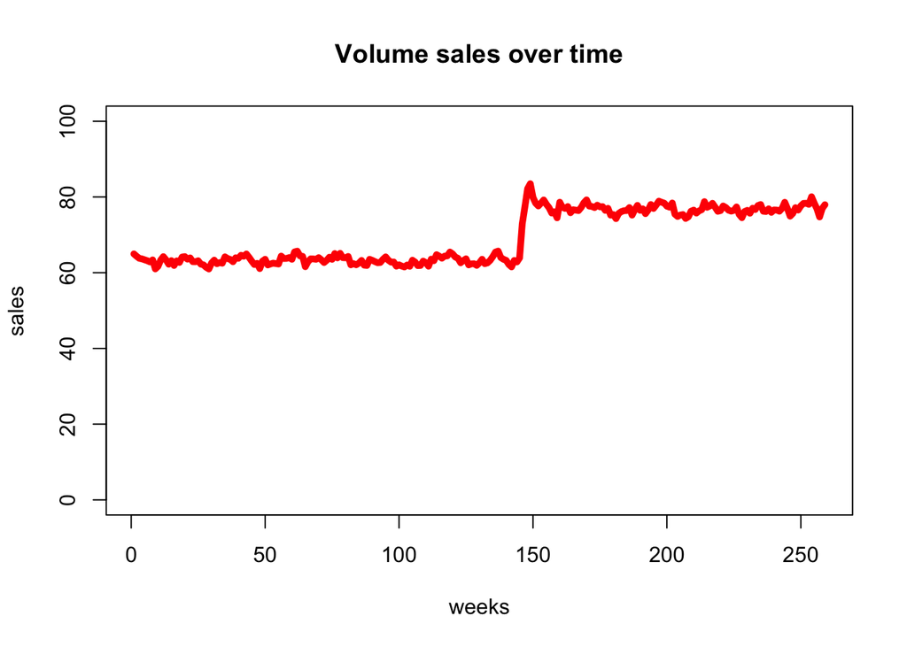

```r
plot(foodcorp.df[,c(1)],foodcorp.df[,c(9)], type="l", col="red", lwd=5, xlab="weeks", ylab="sales", main="Volume sales over time", ylim = c(0,100))
```

## Step 1: Observe ACF and PACF However, **we will only do so for the period before the intervention**. In this case, it’s up to approx. week 144.

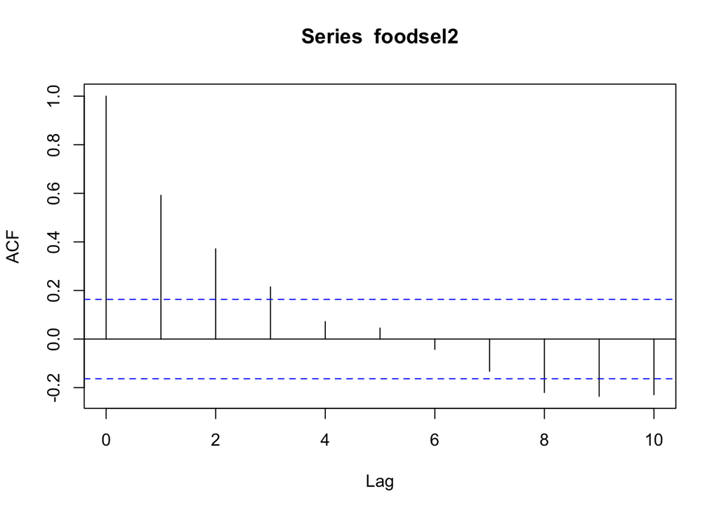

```r
foodsel = foodcorp.df[,c(9)]
foodsel_x = foodcorp.df[,c(1)]
foodsel2 = foodsel[c(1:144)]
foodsel2_x = foodsel_x[c(1:144)]
foodacf = acf(foodsel2, lag.max = 10)
```

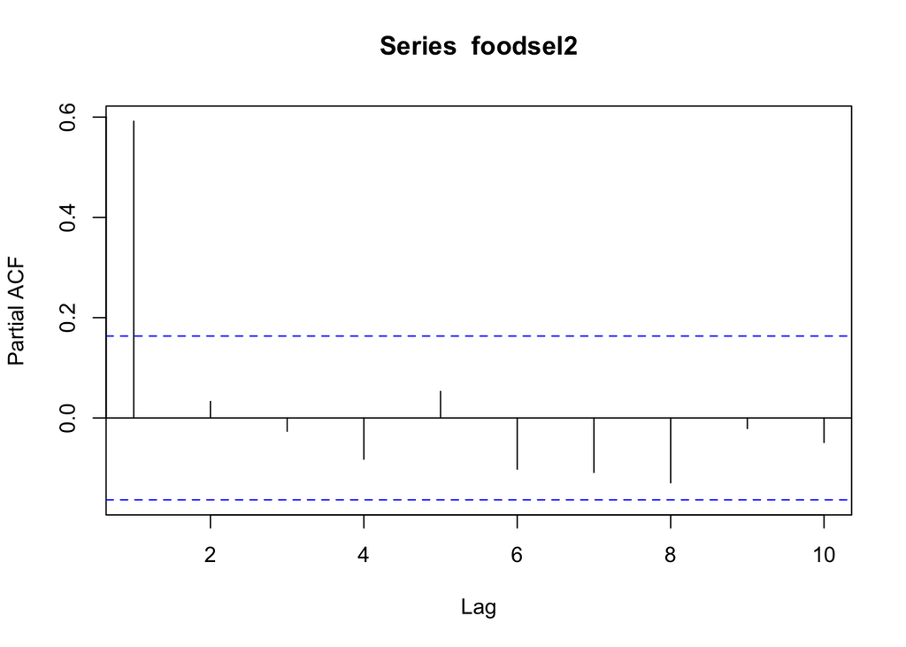

```r
foodpacf = pacf(foodsel2, lag.max = 10)
```

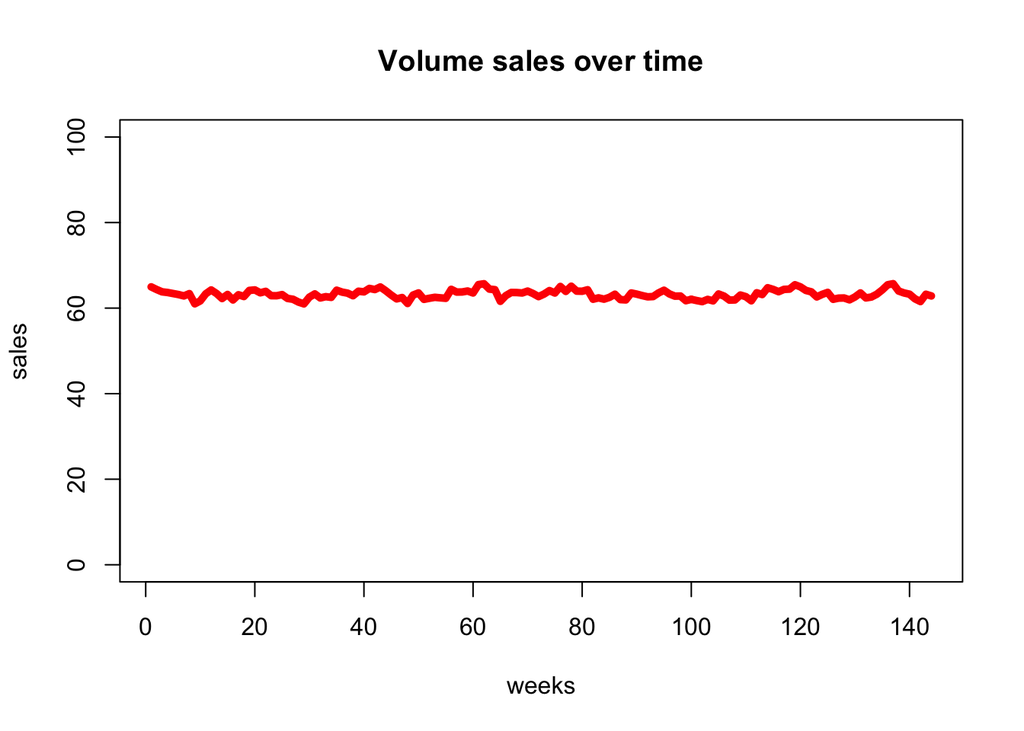

```r
plot(foodsel2_x, foodsel2, type="l", col="red", lwd=5, xlab="weeks", ylab="sales", main="Volume sales over time", ylim = c(0,100))
```

From the looks of it, we seem to have an AR(1) process. There is a single spike in the PACF whilst the ACF plot is slowly decaying.

## Step 2: Observe Unit Roots

```r
adf.test(foodsel2)
```

```
## Augmented Dickey-Fuller Test
## alternative: stationary
##
## Type 1: no drift no trend
##      lag    ADF p.value
## [1,]   0 -0.282   0.562
## [2,]   1 -0.247   0.573
## [3,]   2 -0.222   0.580
## [4,]   3 -0.206   0.584
## [5,]   4 -0.208   0.584
## Type 2: with drift no trend
##      lag   ADF p.value
## [1,]   0 -6.10    0.01
## [2,]   1 -5.23    0.01
## [3,]   2 -4.83    0.01
## [4,]   3 -4.81    0.01
## [5,]   4 -4.19    0.01
## Type 3: with drift and trend
##      lag   ADF p.value
## [1,]   0 -6.09    0.01
## [2,]   1 -5.22    0.01
## [3,]   2 -4.83    0.01
## [4,]   3 -4.81    0.01
## [5,]   4 -4.19    0.01
## ----
## Note: in fact, p.value = 0.01 means p.value <= 0.01
```

```r
pp.test(foodsel2)
```

```
## Phillips-Perron Unit Root Test
## alternative: stationary
##
## Type 1: no drift no trend
##  lag   Z_rho p.value
##    4 -0.0411    0.68
## -----
##  Type 2: with drift no trend
##  lag Z_rho p.value
##    4 -58.8    0.01
## -----
##  Type 3: with drift and trend
##  lag Z_rho p.value
##    4 -58.7    0.01
## ---------------
## Note: p-value = 0.01 means p.value <= 0.01
```

## Step 3: Fit the AR(1) model using Ordinary Least Squaree regression

```r
tssales = as.ts(foodsel2)
# AR is based on its previous value so one lag is required
tsfoodsel3 = ts.intersect(tssales,tssales1=lag(tssales,-1))

m1 <-lm(tssales~tssales1, data=tsfoodsel3, na.action = NULL)
summary(m1)
```

```
##
## Call:
## lm(formula = tssales ~ tssales1, data = tsfoodsel3, na.action = NULL)
##
## Residuals:
##     Min      1Q  Median      3Q     Max
## -2.2871 -0.4473 -0.1185  0.5334  2.1062
##
## Coefficients:
##             Estimate Std. Error t value Pr(>|t|)
## (Intercept) 25.76248    4.22380   6.099 9.69e-09 ***
## tssales1     0.59219    0.06681   8.863 3.06e-15 ***
## ---
## Signif. codes:  0 '***' 0.001 '**' 0.01 '*' 0.05 '.' 0.1 ' ' 1
##
## Residual standard error: 0.8183 on 141 degrees of freedom
## Multiple R-squared:  0.3578, Adjusted R-squared:  0.3532
## F-statistic: 78.56 on 1 and 141 DF,  p-value: 3.058e-15
```

## The same model can be fit using auto.arima but it gives different coefficients.

```r
auto.arima(tssales, test = c("adf"), trace = TRUE)
```

```
##
##  ARIMA(2,0,2) with non-zero mean : Inf
##  ARIMA(0,0,0) with non-zero mean : 418.7304
##  ARIMA(1,0,0) with non-zero mean : 357.5094
##  ARIMA(0,0,1) with non-zero mean : 374.5167
##  ARIMA(0,0,0) with zero mean     : 1604.884
##  ARIMA(2,0,0) with non-zero mean : 359.459
##  ARIMA(1,0,1) with non-zero mean : 359.474
##  ARIMA(2,0,1) with non-zero mean : 361.592
##  ARIMA(1,0,0) with zero mean     : Inf
##
##  Best model: ARIMA(1,0,0) with non-zero mean
```

```
## Series: tssales
## ARIMA(1,0,0) with non-zero mean
##
## Coefficients:
##          ar1     mean
##       0.6004  63.2204
## s.e.  0.0670   0.1689
##
## sigma^2 estimated as 0.679:  log likelihood=-175.67
## AIC=357.34   AICc=357.51   BIC=366.25
```

## Modelling the interventions

```r
tsfoodsel2 = as.ts(foodcorp.df)
tssales = tsfoodsel2[,c(9)]
tsintervent1 = tsfoodsel2[,c(13)]
tsintervent2 = tsfoodsel2[,c(14)]
tsfoodsel4 = ts.intersect(tssales, tssales1=lag(tssales,-1), tsintervent1, tsintervent2)

m2 <-lm(tssales~tssales1 + tsintervent1 + tsintervent2, data=tsfoodsel4, na.action = NULL)
summary(m2)
```

```
##
## Call:
## lm(formula = tssales ~ tssales1 + tsintervent1 + tsintervent2,
##     data = tsfoodsel4, na.action = NULL)
##
## Residuals:
##     Min      1Q  Median      3Q     Max
## -2.2890 -0.5351 -0.0762  0.5957  3.0936
##
## Coefficients:
##              Estimate Std. Error t value Pr(>|t|)
## (Intercept)  27.46578    2.46300  11.151  < 2e-16 ***
## tssales1      0.56534    0.03895  14.515  < 2e-16 ***
## tsintervent1  9.65484    0.62414  15.469  < 2e-16 ***
## tsintervent2 -3.72364    0.47111  -7.904 8.24e-14 ***
## ---
## Signif. codes:  0 '***' 0.001 '**' 0.01 '*' 0.05 '.' 0.1 ' ' 1
##
## Residual standard error: 0.9002 on 254 degrees of freedom
## Multiple R-squared:  0.9835, Adjusted R-squared:  0.9833
## F-statistic:  5045 on 3 and 254 DF,  p-value: < 2.2e-16
```